# Stream C: Introduction to R Programming (BioinfoSummer 2015)

Pengyi Yang & Stephen Pederson

The R programming language provides an effective environment for making sense of data that enables us to address various biological questions. In this introduction course, we will illustrate exploratory data analysis that involves calculating numerical and graphical summaries. More specially, we will cover installation of R packages, write basic R functions and examine various visualization tools. For more intermediate participants in the course we will examine more complex visualization tools.

## Outline

- R data types and operations
- Read data in R and exploratory data analysis
- Install package and calling functions from packages
- Write your own functions
- Generating reports using RStudio

## R data types

#### Atomic data types and operations

**Character**

```r
species <- "mouse"
```

**Integer**

```r
sampleSize <- 6
```

**Numeric**

```r
meanLifeSpan <- 2.05
```

**Factor**

```r
sex <- factor("male")
```

**Boolean**

```r
mammal <- TRUE
```

**Concatenate characters**

```r
strain <- "C57BL/6"
sampleDetail <- paste(species, strain)
sampleDetail
```

```
## [1] "mouse C57BL/6"
```

#### Primitive data types and operations

**Vectors**

```r
Groups <- c("treated", "control", "control", "control", "treated", "treated")
Groups
```

```
## [1] "treated" "control" "control" "control" "treated" "treated"
```

```r
lifeSpans <- c(2.1, 1.9, 1.7, 1.8, 2.3, 2.5)
lifeSpans
```

```
## [1] 2.1 1.9 1.7 1.8 2.3 2.5
```

```r
# Calculate mean life span of sample population
mean(lifeSpans)
```

```
## [1] 2.05
```

**List**

```r
# Split samples based on their groups
sampleByGroup <- split(lifeSpans, Groups)
sampleByGroup # sampleByGroup is a list
```

```
## $control
## [1] 1.9 1.7 1.8
##
## $treated
## [1] 2.1 2.3 2.5
```

```r
# access a single element in a list (get the mean of the second group)
sampleByGroup$treated # access by name using '$'
```

```
## [1] 2.1 2.3 2.5
```

```r
sampleByGroup[[2]] # access by index using '[[]]'
```

```
## [1] 2.1 2.3 2.5
```

```r
# calculate mean of samples in each group
means <- lapply(sampleByGroup, mean)
means
```

```
## $control
## [1] 1.8
##
## $treated
## [1] 2.3
```

```r
# calculate standard deviation of samples in each group
sds <- lapply(sampleByGroup, sd)
sds
```

```
## $control
## [1] 0.1
##
## $treated
## [1] 0.2
```

```r
sds[[2]] # access list by index
```

```
## [1] 0.2
```

**Matrix**

```r
# using cbind (column bind) to combine two vectors into a matrix
mat <- cbind(sampleByGroup$treated, sampleByGroup$control)
mat
```

```
##      [,1] [,2]
## [1,]  2.1  1.9
## [2,]  2.3  1.7
## [3,]  2.5  1.8
```

```r
colnames(mat) <- c("treated", "control") # assign column names
mat
```

```
##      treated control
## [1,]     2.1     1.9
## [2,]     2.3     1.7
## [3,]     2.5     1.8
```

```r
rownames(mat) <- paste("sample", 1:nrow(mat)) # assgin row names
mat
```

```
##          treated control
## sample 1     2.1     1.9
## sample 2     2.3     1.7
## sample 3     2.5     1.8
```

**Data frame**

```r
# create a data frame where life spans are stored in the first column and grouping information are stored in the second column
df <- data.frame(lifeSpans, Groups)
df
```

```
##   lifeSpans  Groups
## 1       2.1 treated
## 2       1.9 control
## 3       1.7 control
## 4       1.8 control
## 5       2.3 treated
## 6       2.5 treated
```

```r
# convert data frame into a list using function 'split'
sampleByGroup <- split(df[,1], df[,2])
sampleByGroup
```

```
## $control
## [1] 1.9 1.7 1.8
##
## $treated
## [1] 2.1 2.3 2.5
```

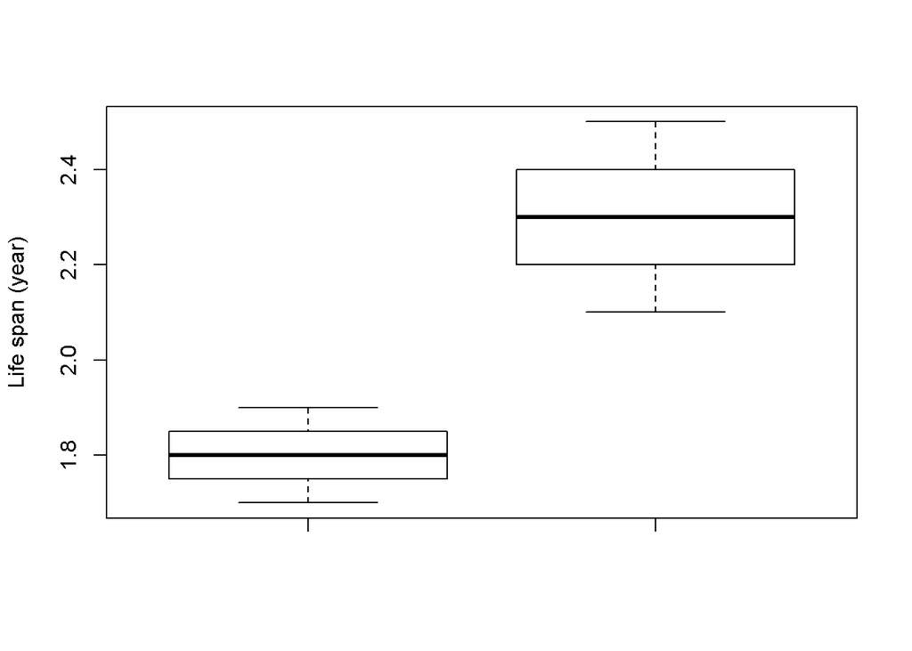

```r
# visualise the data using boxplot
boxplot(sampleByGroup$control, sampleByGroup$treated, ylab="Life span (year)")
```

```r
# perform a t-test with respect to life span between the two groups of samples
g1 <- sampleByGroup$treated
g2 <- sampleByGroup$control
t.test(g1, g2, alternative="greater")
```

```
##
##  Welch Two Sample t-test
##
## data:  g1 and g2
## t = 3.873, df = 2.9412, p-value = 0.01578
## alternative hypothesis: true difference in means is greater than 0
## 95 percent confidence interval:
##  0.1936888       Inf
## sample estimates:
## mean of x mean of y
##       2.3       1.8
```

### Practice 1

Replicate the t-test result above without using the R built-in function ‘t.test’.

Definition of two-sample t-test is as follows:

$H_0$: $\mu_1 = \mu_2$

$H_1$: $\mu_1 \neq \mu_2$

Test statistic:

$T=\frac{\overline{Y}_1 - \overline{Y}_2}{\sqrt{s_1^2/N_1 + s_2^2/N_2}}$

## Reading data in R and exploratory data analysis

#### Read in a tab-delimited dataset from plain text file and calculate summary statistics

```r
Adipo.dat <- read.delim("Adipogenesis.txt", head=TRUE)
Adipo.dat[1:5,]
```

```
##   GeneSymbol    t0.5h      t1h      t2h       t4h        t8h       t48h
## 1      Nr4a1 4.139264 4.695290 4.557286 4.1127582  3.4080955  2.4537373
## 2        Fos 4.389225 4.093885 1.806750 1.2671636  0.8352796  0.5272506
## 3       Btg2 3.989989 3.995800 1.645890 0.7139266 -0.6195376 -0.4145120
## 4      Ptgs2 4.337712 5.460611 4.642035 3.0987586  1.3670011  0.7382098
## 5       Rgs2 2.822143 3.376263 3.523400 3.3030717  2.6106386  2.7989720
```

subsetting a matrix

```r
Adipo.exp <- as.matrix(Adipo.dat[,-1]) # removing the ID column from the raw data to create a numeric matrix containing the expression of the genes at each time point
rownames(Adipo.exp) <- Adipo.dat[,1] # assign the row names of the matrix as the ID in the first column
Adipo.exp[1:5,] # displaying the first five rows of the expression matrix
```

```
##          t0.5h      t1h      t2h       t4h        t8h       t48h
## Nr4a1 4.139264 4.695290 4.557286 4.1127582  3.4080955  2.4537373
## Fos   4.389225 4.093885 1.806750 1.2671636  0.8352796  0.5272506
## Btg2  3.989989 3.995800 1.645890 0.7139266 -0.6195376 -0.4145120
## Ptgs2 4.337712 5.460611 4.642035 3.0987586  1.3670011  0.7382098
## Rgs2  2.822143 3.376263 3.523400 3.3030717  2.6106386  2.7989720
```

```r
summary(Adipo.exp)
```

```
##      t0.5h                t1h                t2h
##  Min.   :-2.187384   Min.   :-1.90305   Min.   :-2.723784
##  1st Qu.:-0.051696   1st Qu.:-0.08715   1st Qu.:-0.123376
##  Median : 0.008043   Median :-0.01620   Median : 0.004174
##  Mean   : 0.010743   Mean   :-0.01216   Mean   :-0.003355
##  3rd Qu.: 0.070590   3rd Qu.: 0.05336   3rd Qu.: 0.106438
##  Max.   : 4.389225   Max.   : 5.46061   Max.   : 5.419228
##       t4h                 t8h                t48h
##  Min.   :-3.546043   Min.   :-4.57534   Min.   :-4.48677
##  1st Qu.:-0.143953   1st Qu.:-0.13082   1st Qu.:-0.11234
##  Median : 0.028906   Median : 0.07001   Median : 0.05885
##  Mean   : 0.003566   Mean   : 0.02734   Mean   : 0.02059
##  3rd Qu.: 0.154741   3rd Qu.: 0.21931   3rd Qu.: 0.19805
##  Max.   : 5.422899   Max.   : 5.22746   Max.   : 6.37389
```

Read data from R data object

```r
load("DEGs.RData") # This data contains differentially expressed genes
# subset the expression matrix to select only DE gene experssions
Adip.exp.DEGs <- Adipo.exp[DEGs,]
```

write table

```r
#write.table(Adip.exp.DEGs, file="Adipogenesis_DE.txt", quote=F, sep="\t")
#save(Adipo.dat, file="Adipo.RData")
```

#### Exploratory data analysis and visualisation

boxplot

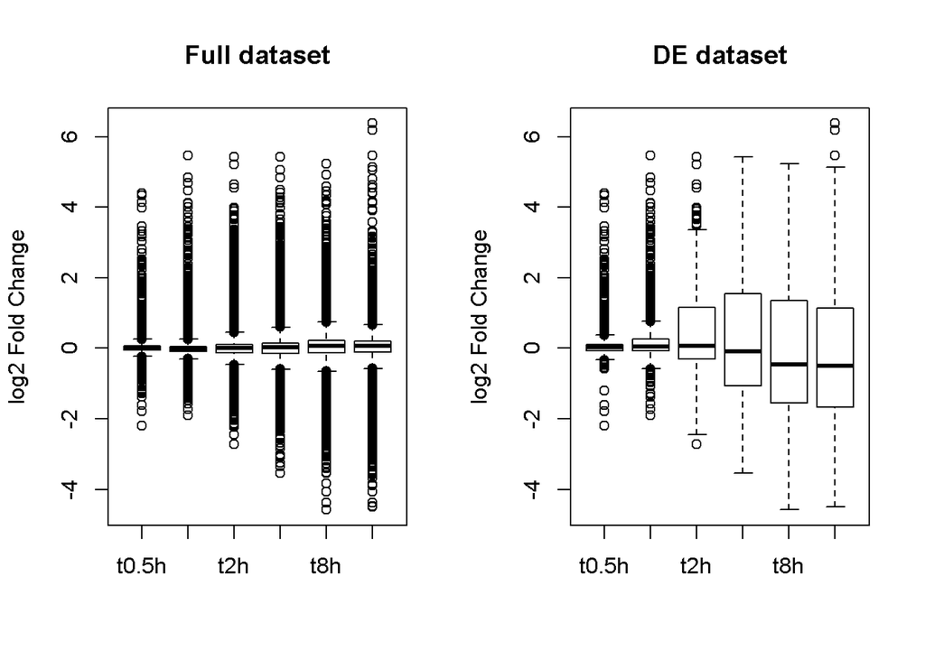

```r
par(mfrow=c(1, 2))
boxplot(Adipo.exp, ylab="log2 Fold Change", main="Full dataset")
boxplot(Adip.exp.DEGs, ylab="log2 Fold Change", main="DE dataset")
```

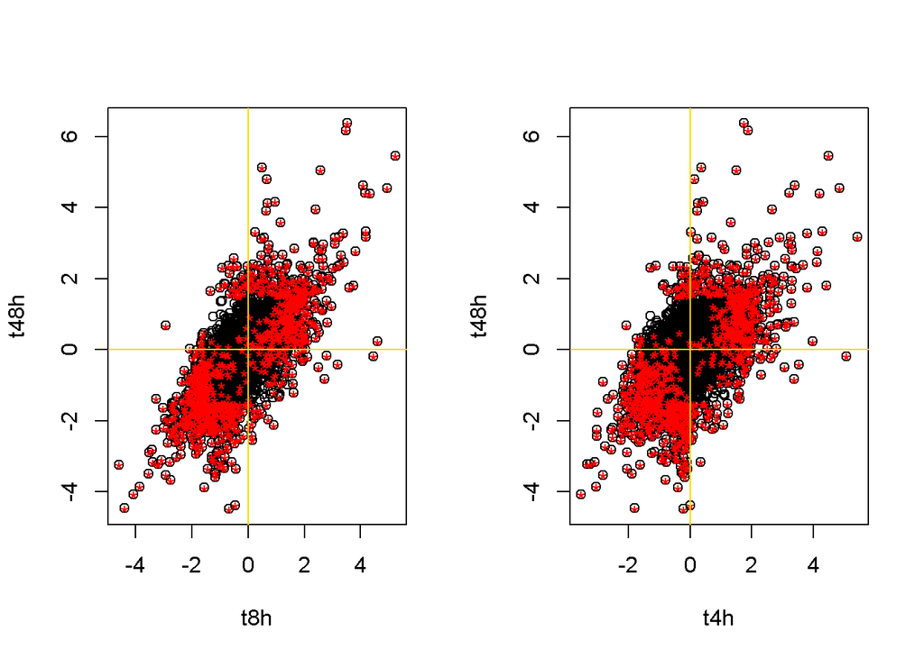

```r
par(mfrow=c(1, 2))
# Scatter plot the full data and highlight the DE genes in the scatter plot
plot(Adipo.exp[,c("t8h", "t48h")])
points(Adipo.exp[DEGs,c("t8h", "t48h")], pch="*", col="red", main="8h vs 48h")
abline(h=0, v=0, col="gold")
# generating pairwise correlation plots
plot(Adipo.exp[,c("t4h", "t48h")])
points(Adipo.exp[DEGs,c("t4h", "t48h")], pch="*", col="red", main="4h vs 48h")
abline(h=0, v=0, col="gold")
```

## Install package and calling functions from packages

Install an R package called ‘corrplot’ from CRAN (The Comprehensive R Archive Network)

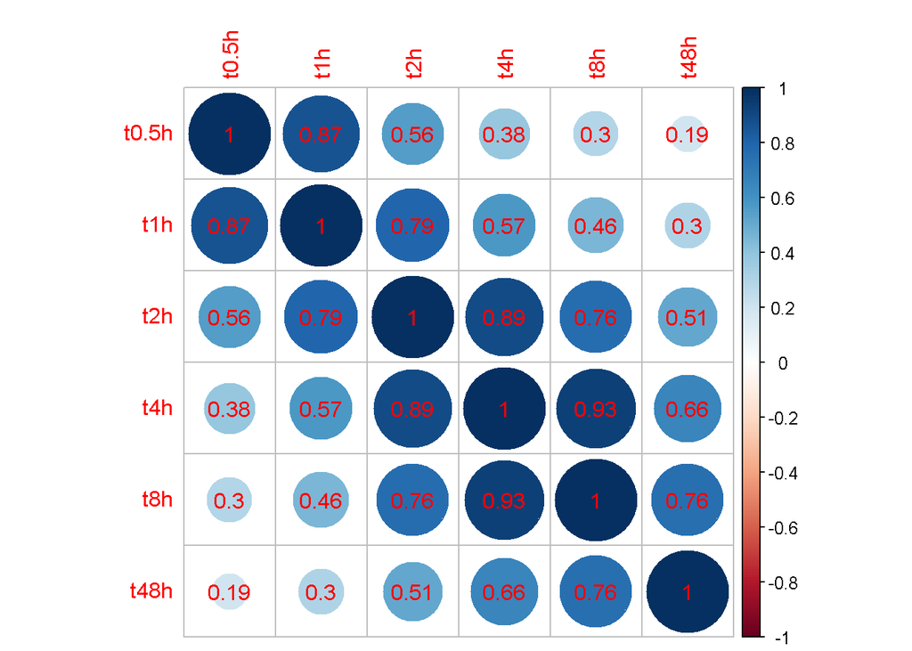

```r
install.packages("corrplot", repos='http://cran.us.r-project.org')
library(corrplot)
#?corrplot
corrplot(corr=cor(Adip.exp.DEGs, use="na.or.complete"), addCoef.col="red")
```

### Practice 2

Cluster evaluation R package (ClueR) is a package to determine optimal fuzzy k-mean clustering from time-series data. Please following the steps below to analyse and visualise the time-series data from Adipogenesis:

**Step 1:** Install an R package called ‘ClueR’ from CRAN.

```
##
##  C:\Users\Pengyi\AppData\Local\Temp\RtmpIp2Mp1\downloaded_packages
```

**Step 2:** Load ‘ClueR’ package in R and run the following three lines of code in R.

```r
data(Pathways)
rownames(Adip.exp.DEGs) <- toupper(rownames(Adip.exp.DEGs))
clueObj <- runClue(Tc=Adip.exp.DEGs, annotation=Pathways.KEGG, rep = 5, kRange=20)
```

```
## repeat 1
## repeat 2
## repeat 3
## repeat 4
## repeat 5
```

**Step 3:** clueObj is a list that contains various evaluation information and statistics. clueObj$evlMat is the evaluation matrix that contains the clustering goodness from k=2 to k=20. Calculate means and standard deviations with respect to each column of this matrix.

**Step 4:** Install an R package called ‘Hmisc’, plot means calculated in step 3, and add standard deviations as error bar using function ‘errbar’ from ‘Hmisc’.

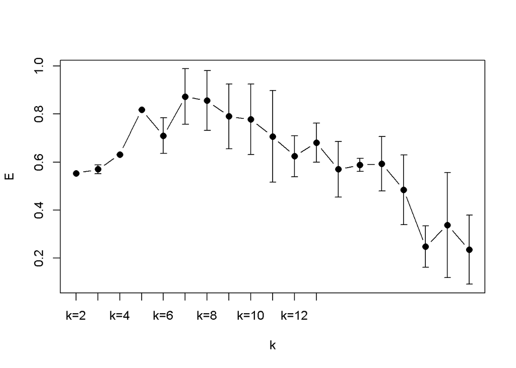

**Step 5:** Run the function “clustOptimal” to obtain optimal clustering result determined by ClueR and access the element called “enrichList” in the output object by “clustOptimal”

```
## $`cluster 1`
##       kinase
##  [1,] "KEGG_FOCAL_ADHESION"
##  [2,] "KEGG_ECM_RECEPTOR_INTERACTION"
##  [3,] "KEGG_DILATED_CARDIOMYOPATHY"
##  [4,] "KEGG_HYPERTROPHIC_CARDIOMYOPATHY_HCM"
##  [5,] "KEGG_REGULATION_OF_ACTIN_CYTOSKELETON"
##  [6,] "KEGG_ARRHYTHMOGENIC_RIGHT_VENTRICULAR_CARDIOMYOPATHY_ARVC"
##  [7,] "KEGG_LEUKOCYTE_TRANSENDOTHELIAL_MIGRATION"
##  [8,] "KEGG_AXON_GUIDANCE"
##  [9,] "KEGG_CELL_ADHESION_MOLECULES_CAMS"
##       pvalue                 size
##  [1,] "8.29043571407536e-05" "15"
##  [2,] "9.42440819747516e-05" "11"
##  [3,] "0.000338183028383924" "9"
##  [4,] "0.000861652980411677" "9"
##  [5,] "0.00475035889532745"  "10"
##  [6,] "0.00936840654107037"  "8"
##  [7,] "0.0121722236183135"   "5"
##  [8,] "0.0225738809777417"   "7"
##  [9,] "0.0467131201038867"   "5"
##       substrates
##  [1,] "FIGF|ITGB5|ITGA11|PDGFRB|MYL9|ITGA1|THBS1|THBS2|ACTN3|COL1A1|SPP1|THBS3|ITGA8|COL1A2|PAK1"
##  [2,] "ITGB5|ITGA11|ITGA1|THBS1|THBS2|SDC3|COL1A1|SPP1|THBS3|ITGA8|COL1A2"
##  [3,] "ITGB5|TPM1|ITGA11|ITGA1|SGCD|TGFB3|CACNG7|CACNB3|ITGA8"
##  [4,] "ITGB5|TPM1|ITGA11|ITGA1|SGCD|TGFB3|CACNG7|CACNB3|ITGA8"
##  [5,] "ITGB5|ITGA11|PDGFRB|MYL9|ITGA1|FGF7|ACTN3|ITGA8|TMSB4X|PAK1"
##  [6,] "ITGB5|ITGA11|ITGA1|SGCD|CACNG7|CACNB3|ACTN3|ITGA8"
##  [7,] "MYL9|JAM2|VCAM1|MMP9|ACTN3"
##  [8,] "SEMA3A|SEMA3F|EFNB2|SLIT2|SEMA3C|ABLIM1|PAK1"
##  [9,] "JAM2|SDC3|VCAM1|NCAM1|ITGA8"
##
## $`cluster 2`
##      kinase                        pvalue               size
## [1,] "KEGG_MAPK_SIGNALING_PATHWAY" "0.0337402202271888" "6"
##      substrates
## [1,] "DUSP6|GADD45G|GADD45B|JUN|MAP2K3|FGF2"
##
## $`cluster 4`
##      kinase                        pvalue                 size
```

[output cut: 10 more lines]

```
## [2,] "POLR1B|POLR1E|CTPS|POLR3G|ENTPD6"
##
## $`cluster 7`
##      kinase                                         pvalue
## [1,] "KEGG_NEUROACTIVE_LIGAND_RECEPTOR_INTERACTION" "0.0026719169714972"
## [2,] "KEGG_TOLL_LIKE_RECEPTOR_SIGNALING_PATHWAY"    "0.0066840179047437"
## [3,] "KEGG_CALCIUM_SIGNALING_PATHWAY"               "0.0195889790272681"
## [4,] "KEGG_B_CELL_RECEPTOR_SIGNALING_PATHWAY"       "0.0231273835265483"
## [5,] "KEGG_FC_GAMMA_R_MEDIATED_PHAGOCYTOSIS"        "0.0473720069475423"
##      size substrates
## [1,] "9"  "LPAR4|GRPR|PTGER4|NPY1R|TBXA2R|CALCRL|PTGER1|GRIK5|GLRB"
## [2,] "8"  "FOS|IL6|TLR3|MAP2K6|TLR4|MAPK3|AKT3|TLR6"
## [3,] "6"  "GRPR|SLC8A1|TBXA2R|PLCB4|PTGER1|EGFR"
## [4,] "5"  "FOS|DAPP1|RASGRP3|MAPK3|AKT3"
## [5,] "5"  "ASAP3|PLD2|MAPK3|MARCKS|AKT3"
```

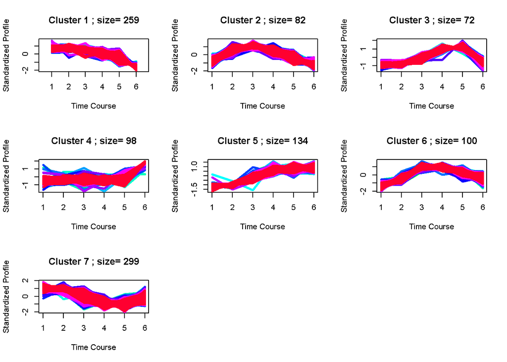